# Presidential Elections in Pennsylvania: 1960-2020

Matthew Grady

June 1, 2021

### Overview

In this work sample, I’ll use R to gather and analyze data from 60 years’ worth of U.S. presidential elections in Pennsylvania. Here’s my plan:

- I’ll piece together the election data from two online sources;
- I’ll use some basic plots to show the results and turnout rates for each election;
- I’ll create a choropleth map to show how Democrat and Republican presidential candidates have performed in each Pennsylvania county over time;
- I’ll create some additional plots to highlight some interesting changes in suburban Philadelphia; and
- I’ll calculate a statistic called the Index of Dissimilarity to understand how Democrat and Republican voters have become more geographically segregated over time.

Before getting started, I’ll load my standard list of R packages.

```r
library(devtools)
library(tidyverse)
library(tidycensus)
library(rgdal)
library(sf)
library(xml2)
library(rvest)
library(tidygeocoder)
library(cowplot)
library(ggrepel)
library(extrafont)
loadfonts(device="win", quiet=TRUE)
```

### Getting the Election Data

County-level results for the 1960 through 1996 presidential elections in Pennsylvania are available online through the Wilkes University Election Statistics Project<sup>1</sup>. The project website contains a separate page for each election, and each page contains an html table with the corresponding county-level results.

I’ll use the `xml2` package to scrape the data from the html tables. Then I’ll store the resulting data frames in a list.

```r
election.set = as.character(seq(1960,1996,4))  # the elections I want
base.url = "http://staffweb.wilkes.edu/harold.cox/pres/PaPres"  # the base url for the site

e.list = list() # an empty list to hold the data frames
for (i in 1:length(election.set)){ # loop through the html tables
  url = paste(base.url, election.set[i], sep='')
  url = paste(url, ".html", sep='') # specify the full url for the election
  e.list[[i]] = html_table(read_html(url), fill=T)[[1]]  # scrape data and add to the list
  e.list[[i]]$Election.Name = election.set[i] # add an election identifier for later
}
```

Next I’ll define a data cleaning function and apply it to each data frame in my list. The cleaning function will remove the variables I don’t need, and make a few other modifications to ensure each data frame is standardized. After applying the cleaning function, I’ll combine all of the resulting data frames together.

```r
df.clean = function(x) { # create the cleaning function
  x %>%
    filter(! County %in% c('','Pennsylvania')) %>%  # remove the state totals
    select_if(! names(.) %in% c('Total Vote','Plurality','Winner','Pct Rep','Pct Dem',
                                'Pct Other','Pct AIP','Pa Perot')) %>% # remove unneeded vars
    mutate_if(is.numeric, as.character) %>% # convert numeric to character
    pivot_longer(! c(County, Election.Name), names_to="Party.Name", values_to="Votes") %>%
    rename(County.Name = County)
}
e.old = lapply(e.list, df.clean) # apply the cleaning function to each data frame in the list
e.old = do.call(rbind.data.frame, e.old) # combine everything into a single data frame
```

County-level results for the 2000 through 2020 presidential elections are available through the Pennsylvania Department of State<sup>2</sup>. I couldn’t find any html tables to scrape, so I downloaded the individual comma-separated results files through the State Department’s reporting system, and saved them locally using a standardized file naming system that would facilitate their efficient importation into R. I’ll use a loop to input and clean the files before combining them into a single data frame.

```r
election.set2 = as.character(seq(2000,2020,4))  # the elections I want
base.path = 'C:/Users/Matt/Desktop/Matt/2020-11-25/1. PA 2020 election/Data sets/'

e.list2 = list() # an empty list to hold the data frames
for (i in 1:length(election.set2)){
  path = paste(base.path, election.set2[i], sep='')
  path = paste(path, "_PA_county_results.txt", sep='') # specify the path to the csv file
  e.list2[[i]] = read.csv(file=path)  # input the csv file
  e.list2[[i]]$Election.Name = election.set2[i] # add an election identifier
  e.list2[[i]] = e.list2[[i]][c('Election.Name','County.Name','Party.Name','Votes')]
}
e.new = do.call(rbind.data.frame, e.list2) # combine everything into one data frame
```

Lastly, I’ll combine the data frame that contains the the 1960-1996 results with the one that contains the 2000-2020 results. This establishes the core data set I’ll use in most of the subsequent analyses.

```r
e.old = e.old[names(e.new)]
e = rbind(e.old, e.new) # bind the two data sets together

e$County.Name = toupper(e$County.Name) # convert county names to "all caps" for easy merging
e$Votes = as.numeric(gsub(",","", e$Votes))  # make the Votes field numeric with no commas
head(e)
```

```
## # A tibble: 6 x 4
##   Election.Name County.Name Party.Name       Votes
##   <chr>         <chr>       <chr>            <dbl>
## 1 1960          ADAMS       Republican       12933
## 2 1960          ADAMS       Democratic        7895
## 3 1960          ADAMS       Socialist Labor     11
## 4 1960          ADAMS       Workers              9
## 5 1960          ADAMS       Scattering           6
## 6 1960          ALLEGHENY   Republican      320970
```

### State-level Results

I’d first like to get a sense of how Democrat and Republican presidential candidates have performed in Pennsylvania over time. For each election, I’ll calculate the statewide Democrat-Republican margin, which I’ll define as the percentage of the vote won by the Democrat candidate minus the percentage won by the Republican candidate.

```r
election.margins = e %>%
  group_by(Election.Name, Party.Name) %>%
  summarize(Votes = sum(Votes, na.rm=T)) %>%
  mutate(Percent=Votes/sum(Votes, na.rm=T)*100) %>%
  summarize(D.Margin.Percent = Percent[Party.Name=='Democratic'] - Percent[Party.Name=='Republican']) %>%
  mutate(Winner = as.factor(ifelse(D.Margin.Percent > 0, 'Democratic','Republican')))
```

Next I’ll create a bar plot to show the statewide Democrat-Republican margin for each election. I’ll start by specifying the core syntax for the bar plot.

```r
bar.plot = ggplot(election.margins, aes(x=Election.Name,
                                            y=D.Margin.Percent, fill=Winner)) +
  geom_bar(stat="identity") +
  scale_fill_manual(values=c("#2166ac", "#b2182b")) +
  scale_y_continuous(name='Democrat-Republican Margin\n', breaks=seq(-20,30,5),
                     limits=c(-22,32), expand=c(0,0), labels=c('-20%','-15%','-10%',
                                                               '-5%','0%','5%','10%','15%',
                                                               '20%','25%','30%')) +
  scale_x_discrete(labels=c("'60","'64","'68","'72","'76","'80","'84","'88",
                            "'92","'96","'00","'04","'08","'12","'16","'20"),
                   name='\nElection Year') +
  labs(title="Democrats have won seven of the last eight presidential elections in Pennsylvania",
       subtitle = "Presidential Election Results for Pennsylvania: 1960-2020")
```

Next, I’ll make some specific formatting changes to the plot.

```r
bar.plot = bar.plot +
  theme(
    axis.line = element_line(size=.5, color='gray50'),
    legend.position = "none",
    legend.text = element_text(family='Segoe UI'),
    axis.text = element_text(size=10, family='Segoe UI'),
    axis.title = element_text(family='Segoe UI'),
    plot.title = element_text(size=12, face='bold', hjust=.5, family='Segoe UI'),
    plot.subtitle = element_text(size=12, hjust=.5, family='Segoe UI')
  )
```

And finally, I’ll add a few annotations to highlight the elections with the largest margins.

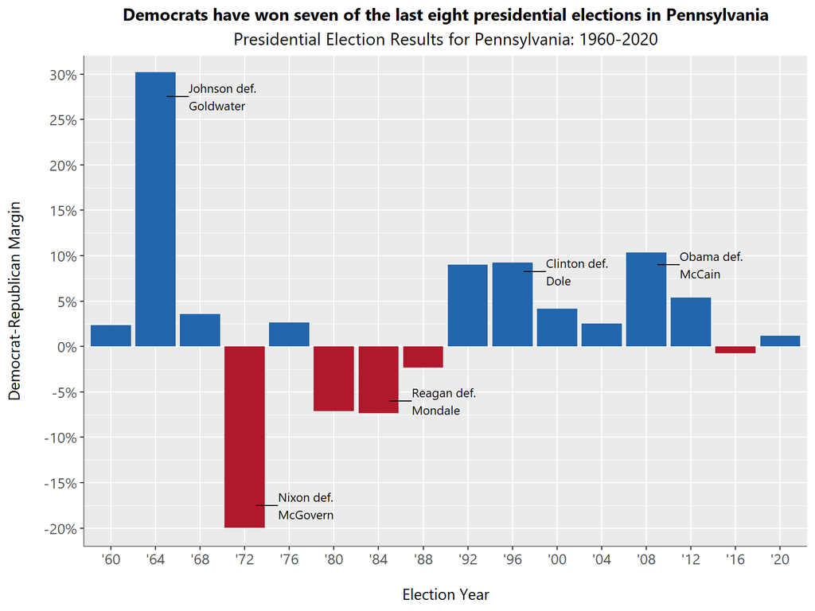

```r
bar.plot = bar.plot +
  geom_segment(aes(x=7.25, y=-6, xend=7.75, yend=-6)) +
  annotate("text", x=7.75, y=-6, hjust='left', family='Segoe UI',
           label = "Reagan def.\nMondale", size=3, color='black') +
  geom_segment(aes(x=13.25, y=9, xend=13.75, yend=9)) +
  annotate("text", x=13.75, y=9, hjust='left', family='Segoe UI',
           label = "Obama def.\nMcCain", size=3, color='black') +
  geom_segment(aes(x=2.25, y=27.5, xend=2.75, yend=27.5)) +
  annotate("text", x=2.75, y=27.5, hjust='left', family='Segoe UI',
           label = "Johnson def.\nGoldwater", size=3, color='black') +
  geom_segment(aes(x=4.25, y=-17.5, xend=4.75, yend=-17.5)) +
  annotate("text", x=4.75, y=-17.5, hjust='left', family='Segoe UI',
           label = "Nixon def.\nMcGovern", size=3, color='black') +
  geom_segment(aes(x=10.25, y=8.25, xend=10.75, yend=8.25)) +
  annotate("text", x=10.75, y=8.25, hjust='left', family='Segoe UI',
           label = "Clinton def.\nDole", size=3, color='black')

bar.plot
```

From the bar plot, I can see that the Democrati candidate for president has defeated the Republican candidate in 11 of the last 16 elections, including seven of the last eight. Prior to Donald Trump’s win over Hillary Clinton in 2016, a Republican presidential candidate had not won Pennsylvania since George H.W. Bush defeated Michael Dukakis in 1988. It’s also immediately clear from the plot that Pennsylvania has seen two absolute landslide victories since 1960. The first was in 1964 when Lyndon Johnson defeated Barry Goldwater by more than 30 points. The second was Richard Nixon’s 20-point win over George McGovern in 1972 – a race where Nixon won all but one of the state’s 67 counties.

### Voter Turnout

Next, I’ll look at voter turnout for each election. Turnout data from 1960 through 2016 are available on the Pennsylvania Department of State website. Different measures of voter turnout are available, but for this work sample, I’ll define turnout as the percentage of the voting age population that actually voted.

I’ll start by scraping the 1960-2016 turnout data directly from the Department of State website. Then I’ll do some data cleaning before manually adding the turnout value for 2020 (which I found through a Google search). Lastly, I’ll add the turnout data to the data frame that contains the statewide election results.

```r
url = 'https://www.dos.pa.gov/VotingElections/OtherServicesEvents/VotingElectionStatistics/Pages/VotingElectionStatistics.aspx'
vt = html_table(read_html(url), fill=T)[[1]]

vt = vt[c(3:17),c(1,7)]
vt$X1 = gsub("\u200b", "", vt$X1)
vt$X7 = gsub("\u200b", "", vt$X7)
vt$X7 = as.numeric(substr(vt$X7, 1, 5))
names(vt) = c('Election.Name','Pct.VAP')

vt20 = data.frame(`Election.Name`=c('2020'), Pct.VAP=c(70.93))
vt = rbind(vt, vt20)

election.margins = merge(election.margins, vt, by='Election.Name')
```

Next I’ll create a line plot that shows the turnout rate for each election. I’ll start with the core syntax for the line plot.

```r
line.plot.vt = ggplot(election.margins, aes(x=Election.Name, y=Pct.VAP, group=1)) +
  geom_line(color='gray75', size=.75) +
  geom_point(aes(color=Winner), size=3) +
  scale_color_manual(values=c("#2166ac", "#b2182b"), labels=c('Democrat victory','Republican victory')) +
  scale_y_continuous(name='Voter Turnout\n', breaks=seq(0,100,10),
                     limits=c(0,100), expand=c(0,0), labels=c('0%','10%','20%','30%','40%','50%','60%','70%','80%','90%','100%'), position='right', sec.axis=dup_axis()) +
  scale_x_discrete(labels=c("'60","'64","'68","'72","'76","'80","'84","'88",
                            "'92","'96","'00","'04","'08","'12","'16","'20"), name='\nElection Year') +
  labs(title="In Pennsylvania, the 2020 presidential election saw record voter turnout",
       subtitle="Voter Turnout for Presidential Elections in Pennsylvania: 1960-2020",
       caption = "\nNote. Here, voter turnout represents the percentage of the voting age population that actually voted.") +
  guides(color = guide_legend(nrow = 1))
```

Next, I’ll make some formatting changes to the plot.

```r
line.plot.vt = line.plot.vt +
  theme(
    axis.line = element_line(size=.5, color='gray50'),
    axis.text = element_text(size=10, family='Segoe UI'),
    axis.title = element_text(family='Segoe UI'),
    plot.title = element_text(size=12, face='bold', hjust=.5, family='Segoe UI'),
    plot.subtitle = element_text(size=12, hjust=.5, family='Segoe UI'),
    plot.caption = element_text(size=9, family='Segoe UI', color='gray30', hjust=0),
    panel.grid.minor = element_blank(),
    axis.title.y.right = element_blank(),
    legend.position = c(.5, .95),
    legend.title = element_blank(),
    legend.background = element_rect(color='gray80', fill='gray95'),
    legend.key = element_rect(fill=NA, color=NA),
    legend.margin = margin(2, 6, 2, 0),
    legend.spacing.x = unit(0, "mm"),
    legend.spacing.y = unit(0, "mm")
  )
```

And finally, I’ll add some annotations to highlight elections with especially high or low turnout rates.

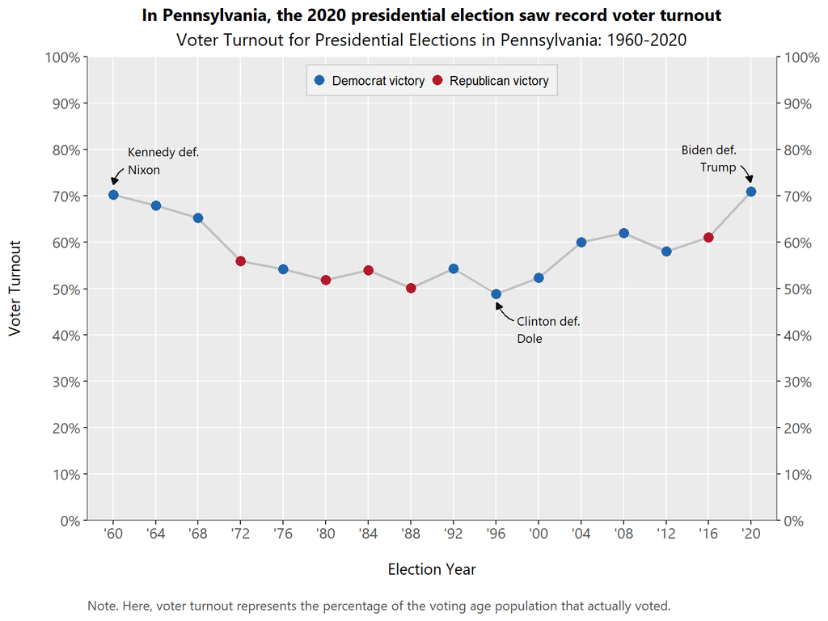

```r
line.plot.vt = line.plot.vt +
  geom_curve(aes(xend=10.02, yend=47.0, x=10.42, y=43), color='black', size=.4,
              curvature=-.2, arrow = arrow(length=unit(.015, "npc"), type='closed')) +
  annotate("text", x=10.5, y=43, hjust='left', vjust=.8, family='Segoe UI',
           label = "Clinton def.\nDole",
           size=3, color='black') +
  geom_curve(aes(xend=15.98, yend=73.0, x=15.75, y=76.5), color='black', size=.4,
             curvature=-.2, arrow = arrow(length=unit(.015, "npc"), type='closed')) +
  annotate("text", x=15.65, y=76.5, hjust='right', vjust=.2, family='Segoe UI',
           label = "Biden def.\nTrump",
           size=3, color='black') +
  geom_curve(aes(xend=1, yend=72.5, x=1.25, y=76), color='black', size=.4,
             curvature=.2, arrow = arrow(length=unit(.015, "npc"), type='closed')) +
  annotate("text", x=1.35, y=76, hjust='left', vjust=.2, family='Segoe UI',
           label = "Kennedy def.\nNixon", size=3, color='black')

line.plot.vt
```

As the line plot shows, voter turnout was relatively high throughout the 1960s before decreasing substanially in 1972. Turnout then remained relatively low until 2004, when it exceeded 60% for the first time in more than 30 years. With a turnout rate of 70.9%, the 2020 election saw the highest rate in the period included here, barely beating the previous high of 70.3% from 1960.

### County-level Results

The statewide results helped me get my bearings, but I’m also intested in identifying interesting trends for specific counties or regions within the state. From this point forward, I’ll focus on county-level results.

My first goal is to create a choropleth map that shows the Democrat-Republican margin for each county, by election. I’ll start by calculating the margins.

```r
county.margins = e %>%
  group_by(Election.Name, County.Name) %>%
  mutate(Percent = (Votes / sum(Votes, na.rm=T))*100) %>%
  summarize(D.Margin.Percent = Percent[Party.Name=='Democratic'] - Percent[Party.Name=='Republican']) %>%  # Get the margin for each county
  mutate(Winner = as.factor(ifelse(D.Margin.Percent > 0, 'Democratic','Republican'))) # identify the winner
```

Now, for each election, I’ll group the counties based on margin. I’ll name the grouping variable `margin.group`.

```r
county.margins$margin.group = cut(county.margins$D.Margin.Percent, breaks=seq(80,-80,-20))
county.margins$margin.group = factor(county.margins$margin.group, levels=rev(levels(county.margins$margin.group))) # classify counties into groups based on margin
```

I’ll create the choropleth map using a county-level shape file I obtained from the IPUMS National Historical Geographic Information System<sup>3</sup>.

First I’ll input the shape file and subset Pennsylvania counties. Then I’ll change the coordinate reference system, and create a “fortified” version of the file, which I’ll use to create the choropleth map with `ggplot2`.

```r
county.shape = readOGR("C:/Users/Matt/Desktop/Matt/2020-11-25/1. PA 2020 election/Shape files", "US_county_2018", verbose=F)

county.shape = county.shape[county.shape$STATEFP == '42',] # subset Pennsylvania
county.shape.sf = st_as_sf(county.shape)
county.shape.sf = st_transform(county.shape.sf, "+proj=longlat +ellps=WGS84 +datum=WGS84") # change the projection
county.shape = as(county.shape.sf, 'Spatial')

county.shape$County.Name = toupper(sub(' .*', '', county.shape$NAME)) # change to uppercase
county.shape.fort = fortify(county.shape, region='County.Name') # fortify the shape file
```

Next I’ll combine the fortified shape file with the county-level election results.

```r
county.margins$id = county.margins$County.Name
d = merge(county.shape.fort, county.margins, by='id') # combine shape file and data
d = d[order(d$order),]
```

Now I’ll use `ggplot2` to create the choropleth map. Each county will be shaded based on its Democrat-Republican margin, as indicated by the discrete `margin.group` variable I created earlier. I’ll use a colorblind-friendly, blue-to-red color palette that I got from the ColorBrewer website<sup>4</sup>.

Importantly, I’ll include the `facet_wrap` command in the syntax so that a separate map is generated for each election.

```r
margin.map = ggplot() +
  geom_polygon(data=d,
               aes(x=long, y=lat, group=group, fill=margin.group),
               color='gray80', size=0.25) +
  scale_fill_manual(values=c('#2166ac','#4393c3','#92c5de','#d1e5f0',
                             '#fddbc7','#f4a582','#d6604d','#b2182b'),
                    name='Democrat-Republican\nMargin (%)') +
  facet_wrap(~Election.Name, ncol=4) +
  labs(title="Presidential Election Results for Pennsylvania Counties: 1960-2020\n") +
  coord_map()
```

Next, I’ll make some specific formatting changes to the map.

```r
margin.map = margin.map +
  theme(
    axis.title = element_blank(),
    axis.text = element_blank(),
    axis.ticks = element_blank(),
    panel.background = element_rect(fill='gray95'),
    panel.grid.major = element_line(color='gray95'),
    plot.title = element_text(size=13, face='bold', hjust=.5, family='Segoe UI'),
    strip.text = element_text(size=10, family='Segoe UI'),
    legend.title = element_text(size=9, family='Segoe UI'),
    legend.text = element_text(family='Segoe UI', size=9)
  )
```

And finally, I’ll label some of the major cities.

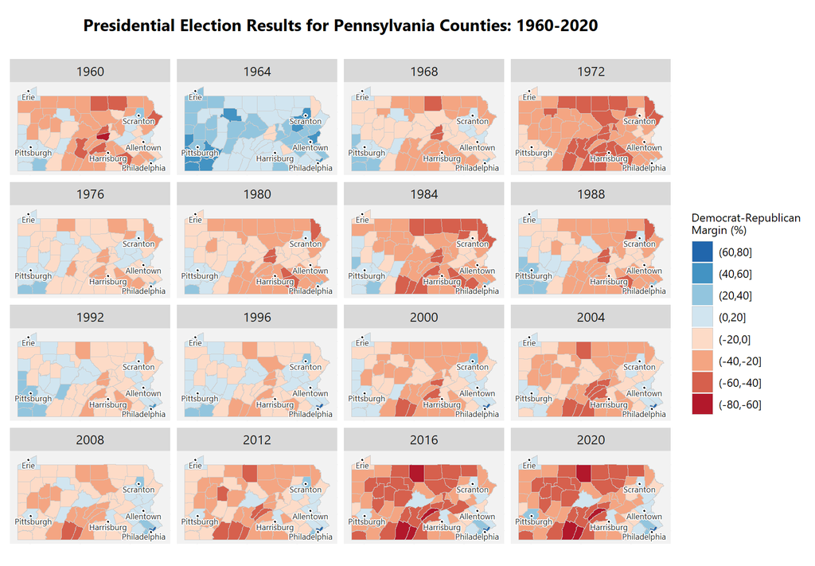

```r
cities = c('Philadelphia','Pittsburgh','Allentown, Pennsylvania','Erie,
           Pennsylvania','Scranton, Pennsylvania', 'Harrisburg, Pennsylvania')
geos = geo(address = c(cities), method = 'osm')
geos$names = c('Philadelphia','Pittsburgh','Allentown','Erie','Scranton','Harrisburg')

margin.map = margin.map +
  geom_point(data=geos[1:6,], aes(x=long, y=lat), size=.8, shape=21,
             color='white', fill='black', stroke=1) +
  geom_text_repel(data=geos[1:6,], aes(x=long, y=lat, label=names), size=2.3, color='gray15', nudge_x=0, nudge_y=-.15, direction='y', family='Segoe UI', bg.colour='white', bg.r=.15, force_pull=1, force=0)

margin.map
```

The choropleth map is overwhelming at first, but after a few minutes of studying it, I can pick up on some trends that I want to explore more closely with some additional plots. The first trend concerns four counties in the southeastern part of the state which I’ll define as suburban Philadelphia: Montgomery, Bucks, Chester and Delaware. Until 1992, these four counties formed a Republican-leaning wall around heavily Democratic Philadelphia, but since that time, they have become increasingly blue.

The second trend I noticed in the choropleth map is that the margins for many counties seem to have grown larger in absolute value in 2016 and 2020. This is evident from the deeper shades of red and blue that appear in the map for those years. This seems to indicate an increased level of geographic segregation of Democrat and Republican voters. I’ll explore this trend later using a statistic called the Index of Dissimilarity.

Finally, I think it’s worth noting that the choropleth map would be misleading to someone who was mainly interested in understanding results at the state level. If I hadn’t already looked at the state-level election results using a bar plot, I’d assume that Pennsylvania was heavily Republican due to the fact that most counties on the map are shaded red. The fact that many of the predominantly Republican counties are sparsely populated, explains why Democrats have historically won Pennsylvania, despite the fact that most counties are won by the Republican candidate.

### Suburban Philadelphia

Next, I’d like to create a bar plot that shows how the four counties around Philadelphia have shifted toward the Democratic Party over time. I’ll begin by subsetting the four counties I’m focusing on.

```r
se.counties = c('MONTGOMERY','BUCKS','CHESTER','DELAWARE')
```

Next I’ll calculate the Democrat-Republican margin for each election, across the four counties.

```r
county.margins.se = e %>%
  filter(County.Name %in% se.counties) %>%
  group_by(Election.Name, Party.Name) %>%
  summarize(Total.Votes = sum(Votes, na.rm=T)) %>%
  group_by(Election.Name) %>%
  mutate(Percent = (Total.Votes / sum(Total.Votes, na.rm=T))*100) %>%
  summarize(D.Margin.Percent = Percent[Party.Name=='Democratic'] - Percent[Party.Name=='Republican']) %>%
  mutate(Winner = ifelse(D.Margin.Percent > 0, 'Democratic','Republican'))
```

Now I’ll create the bar plot to show how the margin has changed over time.

```r
bar.plot.se = ggplot(county.margins.se, aes(x=Election.Name, y=D.Margin.Percent, fill=Winner)) +
  geom_bar(stat="identity") +
  scale_fill_manual(values=c("#2166ac", "#b2182b")) +
  scale_y_continuous(expand=c(0, 0), limits=c(-50, 62), breaks=seq(-50,60,10),
                     name='Democrat-Republican Margin\n', labels=c('-50%','-40%','-30%','-20%',
                                                                   '-10%','0%','10%','20%','30%','40%',
                                                                   '50%','60%')) +
  scale_x_discrete(name='\nElection Year', labels=c("'60","'64","'68","'72","'76","'80","'84","'88",
                                                    "'92","'96","'00","'04","'08","'12","'16","'20")) +
  labs(title="In presidential elections, suburban Philadelphia has shifted from red to blue",
       subtitle="Presidential Election Results for Suburban Philadelphia Counties: 1960-2020",
       caption = "\nNote. Here, suburban Philadephia includes Montgomery, Bucks, Chester, and Delaware Counties.")
```

Next I’ll make some formatting changes to the bar plot.

```r
bar.plot.se = bar.plot.se +
  theme(
    axis.line = element_line(size=.5, color='gray50'),
    panel.background = element_rect(fill='gray93'),
    panel.grid.major = element_line(color='white'),
    panel.grid.minor = element_line(color='gray93'),
    legend.position = "none",
    plot.title = element_text(size=12, face='bold', hjust=.5, family='Segoe UI'),
    plot.subtitle = element_text(size=12, hjust=.5, family='Segoe UI'),
    plot.caption = element_text(size=9, family='Segoe UI', color='gray30', hjust=0),
    axis.title = element_text(family='Segoe UI'),
    axis.text = element_text(family='Segoe UI', size=10)
  )
```

And now I’ll add some annotations.

```r
bar.plot.se = bar.plot.se +
  geom_segment(aes(x=15.65, y=26, xend=16, yend=21)) +
  annotate("text", x=15.5, y=28, hjust='right',
           label = "Biden won suburban\nPhiladelphia by almost 20 points",
           size=3, color='black', family='Segoe UI') +
  geom_segment(aes(x=8.25, y=-20, xend=8.75, yend=-20)) +
  annotate("text", x=8.75, y=-20, hjust='left',
           label = "H.W. Bush won suburban\nPhiladelphia by more than 20 points",
           size=3, color='black', family='Segoe UI')
```

I’ll also create a map that I can set within the bar plot, to show where the four suburban counties are located within the state.

```r
d$southeast = ifelse(d$County.Name %in% se.counties, 'southeast','other')
d$southeast = factor(d$southeast, levels=c('southeast','other'))

inset.map = ggplot() +
  geom_polygon(data=d, aes(x=long, y=lat, group=group, fill=southeast),
               color='white', size=0.25) +
  scale_fill_manual(values=c("gray40", "gray89")) +
  annotate("text", x=-76.104423, y=40.560528, hjust='right',
           label = "Suburban\nPhiladelphia", lineheight=.9,
           size=3, color='gray20', family='Segoe UI') +
  geom_segment(aes(x=-76.023399, y=40.504165, xend=-75.735008, yend=40.329558),
               color='gray20', arrow=arrow(length=unit(.028, "npc"), type='closed')) +
  coord_map()
```

Then I’ll make some formatting changes to the map.

```r
inset.map = inset.map +
  theme(
    axis.title = element_blank(),
    axis.text = element_blank(),
    axis.ticks = element_blank(),
    panel.background = element_rect(fill='white'),
    panel.grid.major = element_line(color='white'),
    plot.background = element_rect(color='black'),
    legend.title = element_text(size=9, family='Segoe UI'),
    legend.background = element_rect(color=NA, fill=NA),
    legend.position = "none"
  )
```

And finally, I’ll create the bar plot with the map inset.

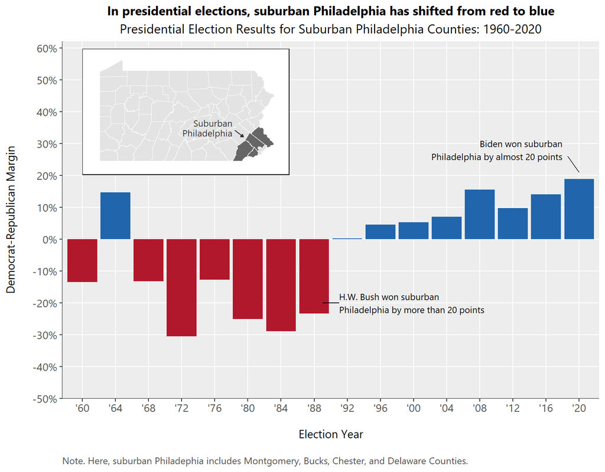

```r
bar.plot.se = bar.plot.se +
  annotation_custom(
    ggplotGrob(inset.map),
    xmin=1, xmax=7.25, ymin=20, ymax=60
  )
bar.plot.se
```

Now I’ll create a bar plot to show how each suburban county has changed over time. I’ll start by subsetting the four counties.

```r
county.margins.se2 = county.margins %>%
  filter(County.Name %in% se.counties)
```

Now I’ll specify the core syntax for the bar plot.

```r
labels.x = c("'60","","'68","","'76","","'84","","'92","","'00","","'08","","'16","")

bar.plot.se2 = ggplot(county.margins.se2, aes(x=Election.Name,
                                            y=D.Margin.Percent, fill=Winner)) +
  geom_bar(stat="identity") +
  scale_fill_manual(values=c("#2166ac", "#b2182b")) +
  scale_y_continuous(breaks=seq(-40,30,10), limits=c(-45,35), expand=c(0,0),
                     name='Democrat-Republican Margin\n', labels=c('-40%','-30%','-20%','-10%','0%',
                                                                   '10%','20%','30%')) +
  scale_x_discrete(name='\nElection Year', labels=labels.x, expand=c(.05,.05)) +
  labs(title="Since 1992, Delaware and Montgomery Counties have become Democratic strongholds",
       subtitle="Presidential Election Results for Suburban Philadelphia Counties: 1960-2020")
```

And finally, I’ll make some formatting changes and add an annotation.

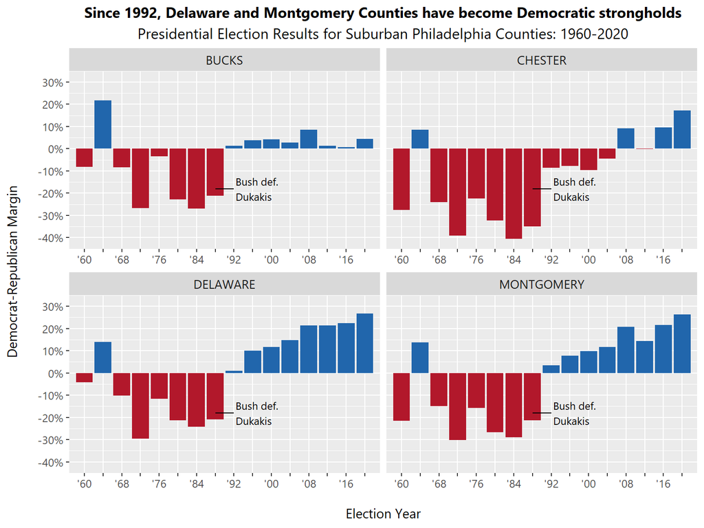

```r
bar.plot.se2 = bar.plot.se2 +
  theme(
    legend.position = "none",
    strip.text = element_text(size=10, family='Segoe UI'),
    plot.title = element_text(size=12, face='bold', hjust=.5, family='Segoe UI'),
    plot.subtitle = element_text(size=12, hjust=.5, family='Segoe UI'),
    axis.title = element_text(family='Segoe UI'),
    axis.text = element_text(family='Segoe UI', size=9)
  ) +
  facet_wrap(~County.Name, ncol=2, scales='free_x') +
  geom_segment(aes(x=8, y=-18, xend=9, yend=-18)) +
  annotate("text", x=9.1, y=-18, hjust='left',
           label = "Bush def.\nDukakis", family='Segoe UI',
           size=3, color='black')

bar.plot.se2
```

### Democrat-Republican Segregation

As a last step, I’d like to determine if Republicans and Democrats in Pennsylvania have become more geographically segregated over time. To understand this, I’ll calculate and plot the Democrat-Republican Index of Dissimilarity for each election.

The Index of Dissimilarity is a measure of geographic segregation between two groups that is typically used to study racial segregation<sup>5</sup>. Here, I’ll use it to assess the degree to which Republican and Democrat voters are segregated across Pennsylvania counties. I’ll calculate the index as follows:

$$D = \frac{1}{2} \sum_{i=1}^{n}\bigl|\frac{P1_{i}}{P1_{T}}- \frac{P2_{i}}{P2_{T}}\bigl|$$

where $P1_{i}$ is the number of Democrat votes cast in county $i$, $P1_{T}$ is the total number of Democrat votes cast statewide, $P2_{i}$ is the number of Republican votes cast in county $i$, and $P2_{T}$ is the total number of Republican votes cast statewide. The index can range from zero to one; here it represents the proportion of Democrat voters that would need to change counties in order for each county in the state to have a Democrat proportion that matches the statewide one.

I’ll start by calculating the index for each election.

```r
e2 = e %>%
  filter(Party.Name %in% c('Democratic','Republican')) %>%
  group_by(Election.Name, Party.Name) %>%
  mutate(State.Votes = sum(Votes)) %>%
  mutate(Ratio = Votes / State.Votes)

e2 = e2 %>%
  group_by(Election.Name, County.Name) %>%
  summarize(Ratio.diff.abs = abs(Ratio[Party.Name=='Democratic'] - Ratio[Party.Name=='Republican']))

e2 = e2 %>%
  group_by(Election.Name) %>%
  summarize(Seg.index = sum(Ratio.diff.abs) / 2)

election.margins = merge(election.margins, e2, by='Election.Name')
```

Now I’ll create a line plot to show how the the index has changed over time.

```r
line.plot = ggplot(election.margins, aes(x=Election.Name, y=Seg.index, group=1)) +
  geom_line(color='gray75', size=.75) +
  geom_point(aes(color=Winner), size=3) +
  scale_color_manual(values=c("#2166ac", "#b2182b"), labels=c('Democrat victory','Republican victory')) +
  scale_y_continuous(expand=c(0, 0), limits=c(.00,.32), breaks=seq(.0,.32,.02),
                     name='Segregation Index\n', sec.axis=dup_axis()) +
  scale_x_discrete(name='\nElection Year', labels=c("'60","'64","'68","'72","'76","'80","'84","'88",
                       "'92","'96","'00","'04","'08","'12","'16","'20")) +
  labs(title="In 2016, Democrat-Republican segregation in Pennsylvania reached a 60-year high",
       subtitle="County-Level Democrat-Republican Segregation for Presidential\nElections in Pennsylvania: 1960-2020") +
  guides(color = guide_legend(nrow = 1))
```

Next, I’ll make some formatting changes to the line plot.

```r
line.plot = line.plot +
  theme(
    axis.line = element_line(size=.5, color='gray50'),
    panel.background = element_rect(fill='gray93'),
    panel.grid.major = element_line(color='white'),
    panel.grid.minor = element_line(color='gray93'),
    plot.title = element_text(size=12, face='bold', hjust=.5, family='Segoe UI'),
    plot.subtitle = element_text(size=12, hjust=.5, family='Segoe UI', lineheight=1.2),
    axis.title = element_text(family='Segoe UI'),
    axis.text = element_text(family='Segoe UI', size=10),
    axis.title.y.right = element_blank(),
    legend.position = c(.5, .95),
    legend.title = element_blank(),
    legend.background = element_rect(color='gray80', fill='gray95'),
    legend.key = element_rect(fill=NA, color=NA),
    legend.margin = margin(2, 6, 2, 0),
    legend.spacing.x = unit(0, "mm"),
    legend.spacing.y = unit(0, "mm")
  )
```

And finally, I’ll add some annotations to highlight elections with especially high indices.

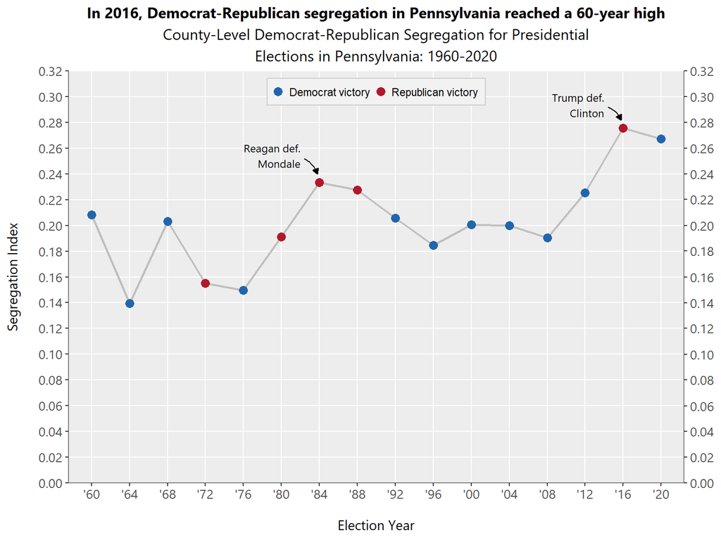

```r
line.plot = line.plot +
  geom_curve(aes(xend=14.95, yend=.282, x=14.6, y=.292), color='black', size=.4,
             curvature=-.2, arrow = arrow(length = unit(.015, "npc"), type='closed')) +
  annotate("text", x=14.5, y=.288, hjust='right', vjust=.2, family='Segoe UI',
             label = "Trump def.\nClinton",
             size=3, color='black') +
  annotate("text", x=6.5, y=0.245, hjust='right', vjust='bottom',
            label = "Reagan def.\nMondale",
            size=3, color='black', family='Segoe UI') +
  geom_curve(aes(xend=6.95, yend=.240, x=6.6, y=.252), color='black', size=.4,
              curvature=-.2, arrow = arrow(length=unit(.015, "npc"), type='closed'))
line.plot
```

Overall, it appears that county-level segregation of Democrat and Republican voters has increased over the past 60 years, although not in a linear way. The index climbed steeply from 1976 to 1984, before gradually decreasing in the years that immediately followed. It again rose sharply from 2008 to 2016, and then remained high in 2020. It will be interesting to see how the index changes in future years, as candidates come and go, and as the Democratic and Republican policy platforms continue to evolve.

### References

<sup>1</sup>The Wilkes University Election Statistics Project, Dr. Harold E. Cox, Director, http://staffweb.wilkes.edu/harold.cox/pres/indexpres.html.

<sup>2</sup>Pennsylvania Department of State, https://www.electionreturns.pa.gov/ReportCenter/Reports.

<sup>3</sup>IPUMS NHGIS, University of Minnesota, www.nhgis.org.

<sup>4</sup>Brewer, Cynthia A., 2020. http://www.ColorBrewer.org, accessed December 27, 2020.

<sup>5</sup>www.CensusScope.org. Social Science Data Analysis Network, University of Michigan. www.ssdan.net.